# M04-A01 - Apriori Helper Functions

## Task 1

With the provided functions, now we could use fpgrowth function to find the frquent itemsets. Let's set the minimum support = 0.05, similar to what we had in Apriori

```python
min_support = 0.05
F, support_data = fpgrowth(dataset, min_support=min_support, include_support=True)

for itemset_group in F:
    for itemset in itemset_group:
        support = support_data[itemset]
        print(f"Frequent Itemset: {set(itemset)}, Support: {support}")
```

```
Frequent Itemset: {'citrus fruit'}, Support: 0.08276563294356888
Frequent Itemset: {'margarine'}, Support: 0.05856634468734113
Frequent Itemset: {'yogurt'}, Support: 0.13950177935943062
Frequent Itemset: {'tropical fruit'}, Support: 0.10493136756481952
Frequent Itemset: {'coffee'}, Support: 0.05805795627859685
Frequent Itemset: {'whole milk'}, Support: 0.25551601423487547
Frequent Itemset: {'pip fruit'}, Support: 0.07564819522114896
Frequent Itemset: {'other vegetables'}, Support: 0.1934926283680732
Frequent Itemset: {'butter'}, Support: 0.05541433655312659
Frequent Itemset: {'rolls/buns'}, Support: 0.18393492628368074
Frequent Itemset: {'bottled beer'}, Support: 0.08052872394509406
Frequent Itemset: {'bottled water'}, Support: 0.11052364006100661
Frequent Itemset: {'curd'}, Support: 0.05327910523640061
Frequent Itemset: {'beef'}, Support: 0.05246568378240976
Frequent Itemset: {'soda'}, Support: 0.17437722419928825
Frequent Itemset: {'frankfurter'}, Support: 0.058973055414336555
Frequent Itemset: {'newspapers'}, Support: 0.07981698017285206
Frequent Itemset: {'fruit/vegetable juice'}, Support: 0.0722928317234367
Frequent Itemset: {'pastry'}, Support: 0.08896797153024912
Frequent Itemset: {'root vegetables'}, Support: 0.10899847483477376
Frequent Itemset: {'canned beer'}, Support: 0.07768174885612608
Frequent Itemset: {'sausage'}, Support: 0.09395017793594305
Frequent Itemset: {'shopping bags'}, Support: 0.09852567361464158
Frequent Itemset: {'brown bread'}, Support: 0.06487036095577021
Frequent Itemset: {'napkins'}, Support: 0.05236400610066091
Frequent Itemset: {'whipped/sour cream'}, Support: 0.07168276563294357
Frequent Itemset: {'pork'}, Support: 0.05765124555160142
Frequent Itemset: {'domestic eggs'}, Support: 0.06344687341128623
Frequent Itemset: {'whole milk', 'yogurt'}, Support: 0.05602440264361973
Frequent Itemset: {'whole milk', 'other vegetables'}, Support: 0.07483477376715811
Frequent Itemset: {'whole milk', 'rolls/buns'}, Support: 0.05663446873411286
```

With the frequent itemsets, we could now gerenate association rules using minimun confidence = 0.05, similar to what we used for Apriori

```python
min_confidence = 0.05
rules = generate_rules(F, support_data, min_confidence=min_confidence, verbose=True)
```

```
{yogurt} ---> {whole milk}:  conf = 0.402, sup = 0.056
{whole milk} ---> {yogurt}:  conf = 0.219, sup = 0.056
{other vegetables} ---> {whole milk}:  conf = 0.387, sup = 0.075
{whole milk} ---> {other vegetables}:  conf = 0.293, sup = 0.075
{rolls/buns} ---> {whole milk}:  conf = 0.308, sup = 0.057
{whole milk} ---> {rolls/buns}:  conf = 0.222, sup = 0.057
```

Define a helper function similar to before

## Task 2

```python
def find_rules_for_different_confidences_and_supports(dataset, support_values, confidence_values):
    results = {}  # Dictionary to hold the number of rules for each (support, confidence) pair

    for min_support in support_values:
        F, support_data = fpgrowth(dataset, min_support=min_support, include_support=True)
        for min_confidence in confidence_values:
            rules = generate_rules(F, support_data, min_confidence=min_confidence, verbose=False)
            if min_support not in results:
                results[min_support] = []
            results[min_support].append(len(rules))

    return results
```

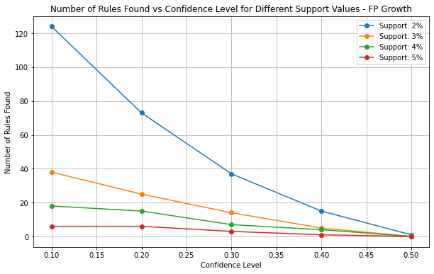

```python
support_values = [0.02, 0.03, 0.04, 0.05]
confidence_values = [0.1, 0.2, 0.3, 0.4, 0.5]

# Get the number of rules for each (support, confidence) pair
results = find_rules_for_different_confidences_and_supports(dataset, support_values, confidence_values)

# Plot the results
plt.figure(figsize=(10, 6))

for support in support_values:
    plt.plot(confidence_values, results[support], marker='o', label=f'Support: {support*100:.0f}%')

plt.xlabel('Confidence Level')
plt.ylabel('Number of Rules Found')
plt.title('Number of Rules Found vs Confidence Level for Different Support Values - FP Growth')
plt.legend()
plt.grid(True)
plt.show()
```

# Part 3 - Interest Factor

Use min_support = 0.02 and min_confidence = 0.3 to generate rules using FPGrowth as Part 2

```python
min_support = 0.02  # 2% support
min_confidence = 0.3  # 30% confidence

F, support_data = fpgrowth(dataset, min_support=min_support, include_support=True)
rules = generate_rules(F, support_data, min_confidence=min_confidence, verbose=True)
```

```
{citrus fruit} ---> {whole milk}:  conf = 0.369, sup = 0.031
{citrus fruit} ---> {other vegetables}:  conf = 0.349, sup = 0.029
{margarine} ---> {whole milk}:  conf = 0.413, sup = 0.024
{yogurt} ---> {whole milk}:  conf = 0.402, sup = 0.056
{yogurt} ---> {other vegetables}:  conf = 0.311, sup = 0.043
{tropical fruit} ---> {other vegetables}:  conf = 0.342, sup = 0.036
{tropical fruit} ---> {whole milk}:  conf = 0.403, sup = 0.042
{pip fruit} ---> {whole milk}:  conf = 0.398, sup = 0.03
{pip fruit} ---> {other vegetables}:  conf = 0.345, sup = 0.026
{other vegetables} ---> {whole milk}:  conf = 0.387, sup = 0.075
{butter} ---> {whole milk}:  conf = 0.497, sup = 0.028
{butter} ---> {other vegetables}:  conf = 0.361, sup = 0.02
{rolls/buns} ---> {whole milk}:  conf = 0.308, sup = 0.057
{bottled water} ---> {whole milk}:  conf = 0.311, sup = 0.034
{curd} ---> {whole milk}:  conf = 0.49, sup = 0.026
{beef} ---> {whole milk}:  conf = 0.405, sup = 0.021
{frankfurter} ---> {whole milk}:  conf = 0.348, sup = 0.021
{newspapers} ---> {whole milk}:  conf = 0.343, sup = 0.027
{fruit/vegetable juice} ---> {whole milk}:  conf = 0.368, sup = 0.027
{pastry} ---> {whole milk}:  conf = 0.374, sup = 0.033
{root vegetables} ---> {other vegetables}:  conf = 0.435, sup = 0.047
{root vegetables} ---> {whole milk}:  conf = 0.449, sup = 0.049
{sausage} ---> {rolls/buns}:  conf = 0.326, sup = 0.031
{sausage} ---> {whole milk}:  conf = 0.318, sup = 0.03
{brown bread} ---> {whole milk}:  conf = 0.389, sup = 0.025
{whipped/sour cream} ---> {whole milk}:  conf = 0.45, sup = 0.032
{whipped/sour cream} ---> {other vegetables}:  conf = 0.403, sup = 0.029
{pork} ---> {whole milk}:  conf = 0.384, sup = 0.022
{pork} ---> {other vegetables}:  conf = 0.376, sup = 0.022
{domestic eggs} ---> {whole milk}:  conf = 0.473, sup = 0.03
{domestic eggs} ---> {other vegetables}:  conf = 0.351, sup = 0.022
{frozen vegetables} ---> {whole milk}:  conf = 0.425, sup = 0.02
{other vegetables, yogurt} ---> {whole milk}:  conf = 0.513, sup = 0.022
{whole milk, yogurt} ---> {other vegetables}:  conf = 0.397, sup = 0.022
{root vegetables, other vegetables} ---> {whole milk}:  conf = 0.489, sup = 0.023
{whole milk, root vegetables} ---> {other vegetables}:  conf = 0.474, sup = 0.023
{whole milk, other vegetables} ---> {root vegetables}:  conf = 0.31, sup = 0.023
```

```python
def calculate_interest_factor(antecedent, consequent, support, support_data):
    support_antecedent = support_data[antecedent]
    support_consequent = support_data[consequent]
    return support / (support_antecedent * support_consequent)

# For each rule in rules, calculate its interest factor
processed_rules = []
for rule in rules:
    antecedent, consequent, confidence = rule
    support = support_data[antecedent | consequent]
    interest_factor = calculate_interest_factor(antecedent, consequent, support, support_data)
    processed_rules.append((antecedent, consequent, support, confidence, interest_factor))
```

Now, prepare three sorted sets by support, confidence, and interest factor, respectively

```python
rules_by_support = sorted(processed_rules, key=lambda x: x[2], reverse=True)
rules_by_confidence = sorted(processed_rules, key=lambda x: x[3], reverse=True)
rules_by_interest = sorted(processed_rules, key=lambda x: x[4], reverse=True)
```

The top 5 rules by support:

```python
for i, rule in enumerate(rules_by_support[:5], 1):
        antecedent, consequent, support, confidence, interest = rule
        print(f"{i}. {set(antecedent)} -> {set(consequent)}")
        print(f"   Support: {support:.4f}, Confidence: {confidence:.4f}, Interest Factor: {interest:.4f}")
```

```
1. {'other vegetables'} -> {'whole milk'}
   Support: 0.0748, Confidence: 0.3868, Interest Factor: 1.5136
2. {'rolls/buns'} -> {'whole milk'}
   Support: 0.0566, Confidence: 0.3079, Interest Factor: 1.2050
3. {'yogurt'} -> {'whole milk'}
   Support: 0.0560, Confidence: 0.4016, Interest Factor: 1.5717
4. {'root vegetables'} -> {'whole milk'}
   Support: 0.0489, Confidence: 0.4487, Interest Factor: 1.7560
5. {'root vegetables'} -> {'other vegetables'}
   Support: 0.0474, Confidence: 0.4347, Interest Factor: 2.2466
```

The top 5 rules by confidence:

```python
for i, rule in enumerate(rules_by_confidence[:5], 1):
        antecedent, consequent, support, confidence, interest = rule
        print(f"{i}. {set(antecedent)} -> {set(consequent)}")
        print(f"   Support: {support:.4f}, Confidence: {confidence:.4f}, Interest Factor: {interest:.4f}")
```

```
1. {'other vegetables', 'yogurt'} -> {'whole milk'}
   Support: 0.0223, Confidence: 0.5129, Interest Factor: 2.0072
2. {'butter'} -> {'whole milk'}
   Support: 0.0276, Confidence: 0.4972, Interest Factor: 1.9461
3. {'curd'} -> {'whole milk'}
   Support: 0.0261, Confidence: 0.4905, Interest Factor: 1.9195
4. {'root vegetables', 'other vegetables'} -> {'whole milk'}
   Support: 0.0232, Confidence: 0.4893, Interest Factor: 1.9148
5. {'whole milk', 'root vegetables'} -> {'other vegetables'}
   Support: 0.0232, Confidence: 0.4740, Interest Factor: 2.4498
```

The top 5 rules by interest factor:

```python
for i, rule in enumerate(rules_by_interest[:5], 1):
        antecedent, consequent, support, confidence, interest = rule
        print(f"{i}. {set(antecedent)} -> {set(consequent)}")
        print(f"   Support: {support:.4f}, Confidence: {confidence:.4f}, Interest Factor: {interest:.4f}")
```

```
1. {'whole milk', 'other vegetables'} -> {'root vegetables'}
   Support: 0.0232, Confidence: 0.3098, Interest Factor: 2.8421
2. {'whole milk', 'root vegetables'} -> {'other vegetables'}
   Support: 0.0232, Confidence: 0.4740, Interest Factor: 2.4498
3. {'root vegetables'} -> {'other vegetables'}
   Support: 0.0474, Confidence: 0.4347, Interest Factor: 2.2466
4. {'whipped/sour cream'} -> {'other vegetables'}
   Support: 0.0289, Confidence: 0.4028, Interest Factor: 2.0819
5. {'whole milk', 'yogurt'} -> {'other vegetables'}
   Support: 0.0223, Confidence: 0.3975, Interest Factor: 2.0541
```

Now we could find the common rules for the three sorted sets. From the results below we can conclude:

1. there is no common rules when we compare the top 5 rules between support and confidence.
2. There is one rule between support and interest factor, which is {'root vegetables'} -> {'other vegetables'}.This implies that Root vegetables and other vegetables are frequently bought together (high support), and maybe these two categories are good candidates to put together for bundle sales.
3. There is one rule between confidence and interest factor, which is {'whole milk', 'root vegetables'} -> {'other vegetables'}. When customers buy whole milk and root vegetables, they are very likely to also buy other vegetables (high confidence). The high interest factor also suggests that this combination occurs more frequently than would be expected by chance.

```python
def rule_to_tuple(rule):
    return (frozenset(rule[0]), frozenset(rule[1]))

# Create sets of top 5 rules for each criterion
top_support = set(map(rule_to_tuple, rules_by_support[:5]))
top_confidence = set(map(rule_to_tuple, rules_by_confidence[:5]))
top_interest = set(map(rule_to_tuple, rules_by_interest[:5]))

# Find common rules across all criteria
common_rules = top_support & top_confidence & top_interest

print("\nCommon rules across all three criteria:")
if common_rules:
    for i, rule in enumerate(common_rules, 1):
        print(f"{i}. {set(rule[0])} -> {set(rule[1])}")
else:
    print("No common rules found across all three criteria.")

# Compare pairs of criteria
pairs = [
    (top_support, top_confidence, "support", "confidence"),
    (top_support, top_interest, "support", "interest factor"),
    (top_confidence, top_interest, "confidence", "interest factor")
]

for set1, set2, name1, name2 in pairs:
    common = set1 & set2
    print(f"\nCommon rules between {name1} and {name2}: {len(common)}")
    if common:
        print("Common rules:")
        for i, rule in enumerate(common, 1):
            print(f"{i}. {set(rule[0])} -> {set(rule[1])}")
```

```
Common rules across all three criteria:
No common rules found across all three criteria.

Common rules between support and confidence: 0

Common rules between support and interest factor: 1
Common rules:
1. {'root vegetables'} -> {'other vegetables'}

Common rules between confidence and interest factor: 1
Common rules:
1. {'whole milk', 'root vegetables'} -> {'other vegetables'}
```